# Divvy Bike Data Analysis

Devanshu Bhargava

2023-11-16

This analysis will go through 6 stages: Ask , Prepare , Process , Analyze ,Share , Act

## **ASK**

#### **About The Company**

In 2016, Cyclistic launched a successful bike-share offering. Since then, the program has grown to a fleet of 5,824 bicycles that are geotracked and locked into a network of 692 stations across Chicago. The bikes can be unlocked from one station and returned to any other station in the system anytime. Until now, Cyclistic’s marketing strategy relied on building general awareness and appealing to broad consumer segments. One 2 approach that helped make these things possible was the flexibility of its pricing plans: single-ride passes, full-day passes, and annual memberships. Customers who purchase single-ride or full-day passes are referred to as casual riders. Customers who purchase annual memberships are Cyclistic members. Cyclistic’s finance analysts have concluded that annual members are much more profitable than casual riders. Although the pricing flexibility helps Cyclistic attract more customers, Moreno believes that maximizing the number of annual members will be key to future growth. Rather than creating a marketing campaign that targets all-new customers, Moreno believes there is a very good chance to convert casual riders into members. She notes that casual riders are already aware of the Cyclistic program and have chosen Cyclistic for their mobility needs. Moreno has set a clear goal: Design marketing strategies aimed at converting casual riders into annual members. In order to do that, however, the marketing analyst team needs to better understand how annual members and casual riders differ, why casual riders would buy a membership, and how digital media could affect their marketing tactics. Moreno and her team are interested in analyzing the Cyclistic historical bike trip data to identify trends.

#### **Business Task:**

Identify trends between riders using historical data in order to implement an effective marketing strategy aimed at converting casual riders into annual members.

## **Prepare**

For this analysis i have downloaded Oct 2023 data CSV file *You can View data from here* [click here](https://divvy-tripdata.s3.amazonaws.com/index.html)

#### **Data Cleaning**

*I opened CSV file in Excel. The file contains 13 columns. I have listed the columns and a short description of each below:*

- ride_id | id of bike rider
- rideable_type | different type of bikes: docked, classic, electric
- started_at | timestamp of when the ride started
- ended_at | timestamp of when the ride ended
- start_station_name | name of the station where bike was retrieved
- start_station_id | specific id where the bike was retrieved
- end_station_name | name of the station where bike was dropped off
- end_station_id | specific id where bike was dropped off
- start_lat | start latitude
- start_lng | start longitude
- end_lat | end latitude
- end_lng | end longitude
- member_casual | type of rider: member, casual

## **Process**

*After analyzing each column i came to an conclusion that:*

**1.We don’t need these columns**

- ride_id | id of bike rider
- start_station_id | specific id where the bike was retrieved
- end_station_id | specific id where bike was dropped off

2.After **Deleting** these column I use **DATA -> Remove Duplicate** in **Excel** to remove any unwanted duplicate data.

3.There are blank cells present in the data to remove them i use **SQL** with **BigQuerry**

`SELECT *`

`` FROM `dotted-medley-402112.cycle_data.cycle_data ``

`WHERE started_at IS NOT NULL AND ended_at IS NOT NULL AND start_station_name !="" AND end_station_name != ""`

#### **Setting up my environment**

Notes: setting up my R environment by loading the ‘tidyverse’,‘ggplot2’, ‘dplyr’, and ‘readr’ packages

```r
library(tidyverse)
library(dplyr)

library(tidyr)

library(readr)
```

##### Upload Divvy dataset (csv files) here

```r
df<- read.csv("F:/202310-divvy-tripdata_asli_wala.csv")
head(df)
```

|  | rideable_type | started_at | ended_at | start_station_name | end_station_name | start_lat | start_lng | end_lat | end_lng | member_casual |
| --- | --- | --- | --- | --- | --- | --- | --- | --- | --- | --- |
| 1 | classic_bike | 2023-10-23 20:40:00 UTC | 2023-10-23 20:42:00 UTC | Wells St & Walton St | Wells St & Institute Pl | 41.89993 | -87.63443 | 41.89738 | -87.63442 | member |
| 2 | classic_bike | 2023-10-05 22:50:00 UTC | 2023-10-05 22:59:00 UTC | Clark St & Lake St | Wells St & Institute Pl | 41.88602 | -87.63088 | 41.89738 | -87.63442 | member |
| 3 | classic_bike | 2023-10-04 18:04:00 UTC | 2023-10-04 18:05:00 UTC | Wells St & Walton St | Wells St & Institute Pl | 41.89993 | -87.63443 | 41.89738 | -87.63442 | member |
| 4 | classic_bike | 2023-10-15 10:56:00 UTC | 2023-10-15 10:59:00 UTC | Wells St & Elm St | Wells St & Institute Pl | 41.90322 | -87.63432 | 41.89738 | -87.63442 | member |
| 5 | classic_bike | 2023-10-20 17:32:00 UTC | 2023-10-20 17:34:00 UTC | Wells St & Walton St | Wells St & Institute Pl | 41.89993 | -87.63443 | 41.89738 | -87.63442 | member |
| 6 | classic_bike | 2023-10-13 08:03:00 UTC | 2023-10-13 08:30:00 UTC | Ashland Ave & Grace St | Wells St & Institute Pl | 41.95069 | -87.66870 | 41.89738 | -87.63442 | member |

```r
str(df)
```

```
## 'data.frame':    403780 obs. of  10 variables:
##  $ rideable_type     : chr  "classic_bike" "classic_bike" "classic_bike" "classic_bike" ...
##  $ started_at        : chr  "2023-10-23 20:40:00 UTC" "2023-10-05 22:50:00 UTC" "2023-10-04 18:04:00 UTC" "2023-10-15 10:56:00 UTC" ...
##  $ ended_at          : chr  "2023-10-23 20:42:00 UTC" "2023-10-05 22:59:00 UTC" "2023-10-04 18:05:00 UTC" "2023-10-15 10:59:00 UTC" ...
##  $ start_station_name: chr  "Wells St & Walton St" "Clark St & Lake St" "Wells St & Walton St" "Wells St & Elm St" ...
##  $ end_station_name  : chr  "Wells St & Institute Pl" "Wells St & Institute Pl" "Wells St & Institute Pl" "Wells St & Institute Pl" ...
##  $ start_lat         : num  41.9 41.9 41.9 41.9 41.9 ...
##  $ start_lng         : num  -87.6 -87.6 -87.6 -87.6 -87.6 ...
##  $ end_lat           : num  41.9 41.9 41.9 41.9 41.9 ...
##  $ end_lng           : num  -87.6 -87.6 -87.6 -87.6 -87.6 ...
##  $ member_casual     : chr  "member" "member" "member" "member" ...
```

##### Formating the Data

```r
df <-df%>%            #using the pipe function of R
    rename(ride_type = rideable_type , customer_type = member_casual)%>%   # renaming the columns names

  # Converting started_at and ended_at columns in  %Y-%m-%d %H:%M:%S format
   mutate(started_at = as.POSIXct(started_at , format = "%Y-%m-%d %H:%M:%S"),
          ended_at = as.POSIXct(ended_at , format="%Y-%m-%d %H:%M:%S"))%>%

  #creating a new column (ride_length) which contains ride lengths in mins
          mutate(ride_length = difftime(ended_at, started_at, units = 'mins'))%>%

  # Converting new column's values (ride_length) into numeric values
  mutate(ride_length_in_mins = as.numeric(ride_length))%>%

  #Filtering ride_length column
  filter(ride_length > 0)%>%

  #creating a temporary column name day_of_week with Dates values
  mutate(day_of_week = as.Date(started_at))%>%

  #replacing the date values with day values
  mutate(day_of_week = format(as.Date(day_of_week), "%A"))
```

```r
head(df)
```

|  | ride_type | started_at | ended_at | start_station_name | end_station_name | start_lat | start_lng | end_lat | end_lng | customer_type | ride_length | ride_length_in_mins | day_of_week |
| --- | --- | --- | --- | --- | --- | --- | --- | --- | --- | --- | --- | --- | --- |
| 1 | classic_bike | 2023-10-23 20:40:00 | 2023-10-23 20:42:00 | Wells St & Walton St | Wells St & Institute Pl | 41.89993 | -87.63443 | 41.89738 | -87.63442 | member | 2 mins | 2 | Monday |
| 2 | classic_bike | 2023-10-05 22:50:00 | 2023-10-05 22:59:00 | Clark St & Lake St | Wells St & Institute Pl | 41.88602 | -87.63088 | 41.89738 | -87.63442 | member | 9 mins | 9 | Thursday |
| 3 | classic_bike | 2023-10-04 18:04:00 | 2023-10-04 18:05:00 | Wells St & Walton St | Wells St & Institute Pl | 41.89993 | -87.63443 | 41.89738 | -87.63442 | member | 1 mins | 1 | Wednesday |
| 4 | classic_bike | 2023-10-15 10:56:00 | 2023-10-15 10:59:00 | Wells St & Elm St | Wells St & Institute Pl | 41.90322 | -87.63432 | 41.89738 | -87.63442 | member | 3 mins | 3 | Sunday |
| 5 | classic_bike | 2023-10-20 17:32:00 | 2023-10-20 17:34:00 | Wells St & Walton St | Wells St & Institute Pl | 41.89993 | -87.63443 | 41.89738 | -87.63442 | member | 2 mins | 2 | Friday |
| 6 | classic_bike | 2023-10-13 08:03:00 | 2023-10-13 08:30:00 | Ashland Ave & Grace St | Wells St & Institute Pl | 41.95069 | -87.66870 | 41.89738 | -87.63442 | member | 27 mins | 27 | Friday |

There is 1 problem here the day_of_week is not in order

```r
#for making day_of_week in order
df <- df %>%
  mutate(day_of_week = ordered(day_of_week, levels = c("Sunday", "Monday", "Tuesday", "Wednesday", "Thursday", "Friday", "Saturday")))
```

## **Analyze**

#### **After preparing the data let’s analyze it**

**Total rides per customers**

```r
# Calculate total rides Per customer
table(df$customer_type)
```

```
##
## casual member
## 129183 270645
```

**Creating a new Data Frame with average ride lengths of customers Per Week**

```r
df_summary <- df %>%
  group_by(day_of_week, customer_type) %>%
  summarise(mean_ride_length = mean(ride_length_in_mins, na.rm = TRUE)) %>%
  ungroup()
head(df_summary)
```

| day_of_week | customer_type | mean_ride_length |
| --- | --- | --- |
| Sunday | casual | 27.32367 |
| Sunday | member | 13.20476 |
| Monday | casual | 20.59152 |
| Monday | member | 11.07990 |
| Tuesday | casual | 19.59217 |
| Tuesday | member | 11.69885 |

**Max ride length per customer**

```r
df_summary%>%
  group_by(customer_type)%>%
  summarise(max(mean_ride_length))
```

| customer_type | max(mean_ride_length) |
| --- | --- |
| casual | 27.32367 |
| member | 13.20476 |

**Min ride length per customer**

```r
df_summary%>%
  group_by(customer_type)%>%
  summarise(min(mean_ride_length))
```

| customer_type | min(mean_ride_length) |
| --- | --- |
| casual | 17.37718 |
| member | 11.07990 |

## **Share**

#### *Visualizing different aspect of the data*

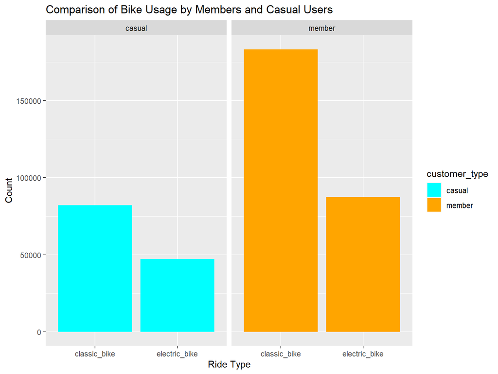

```r
ggplot(data = df, aes(x = ride_type, fill = customer_type)) +
  geom_bar(position = "dodge") +
  labs(title = "Comparison of Bike Usage by Members and Casual Users",
       x = "Ride Type",
       y = "Count") +scale_fill_manual(values = c("casual" = "cyan", "member" = "orange")) +facet_grid(. ~ customer_type)
```

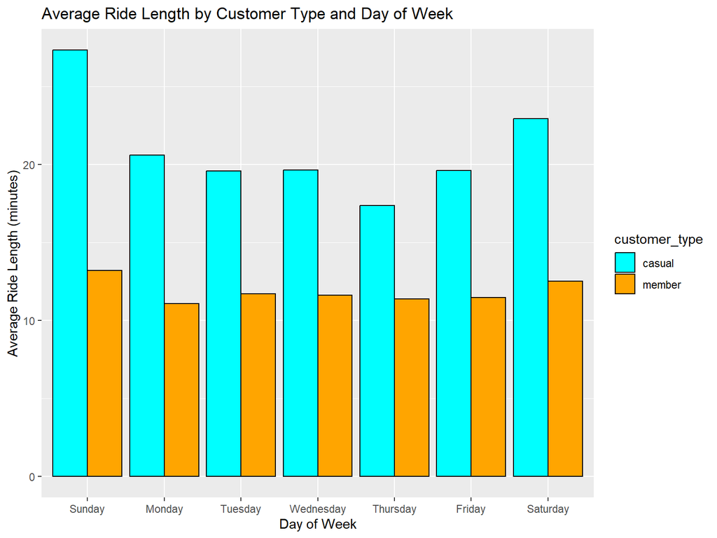

```r
ggplot(data = df_summary, aes(x = day_of_week, y = mean_ride_length, fill = customer_type)) +
  geom_col( position = "dodge" , color= "black") +
  labs(title = "Average Ride Length by Customer Type and Day of Week",
       x = "Day of Week",
       y = "Average Ride Length (minutes)") +scale_fill_manual(values = c("casual" = "cyan", "member" = "orange"))
```

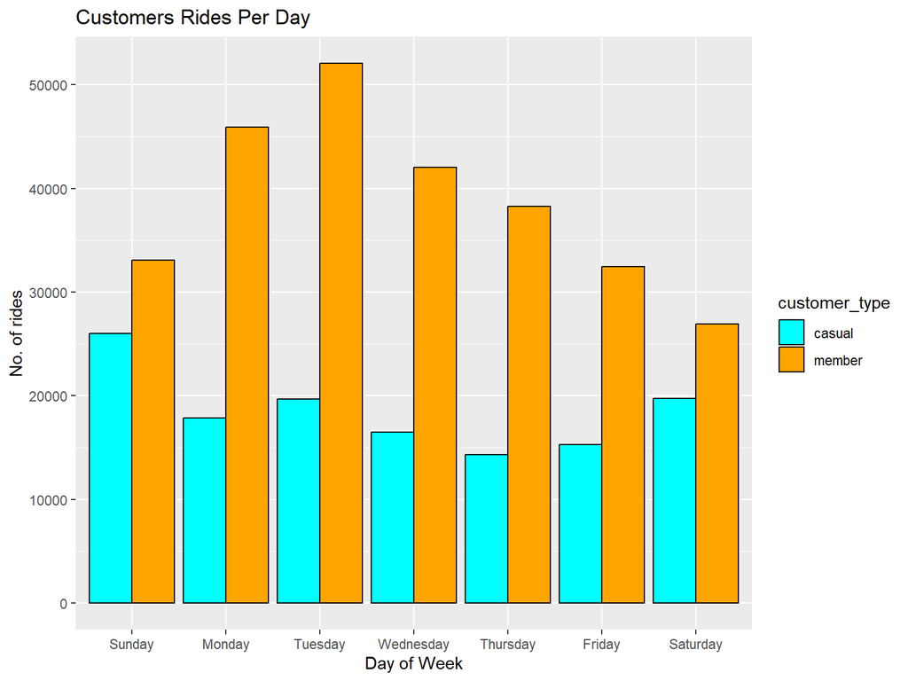

```r
ggplot(data = df, aes(x = day_of_week, fill = customer_type)) +
  geom_bar(position = "dodge" , color = "black" ) + labs(title = "Customers Rides Per Day" , x = "Day of Week" , y = "No. of rides") + scale_fill_manual(values = c("casual" = "cyan", "member" = "orange"))
```

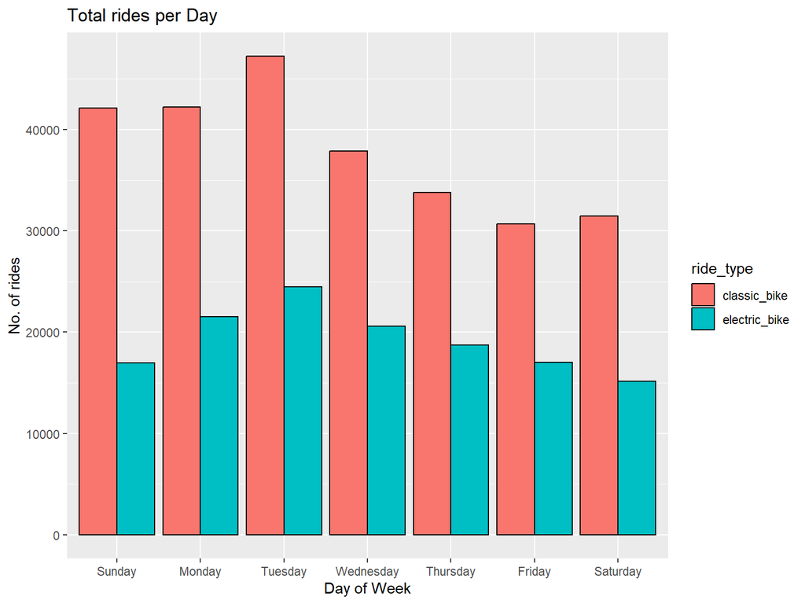

```r
ggplot(data = df, aes(x = day_of_week, fill = ride_type)) +
  geom_bar(position = "dodge" , color = "black" , stat = "count") + labs(title = "Total rides per Day" , x = "Day of Week" , y = "No. of rides")
```

#### *You can View my Tableau* [Dashboard](https://public.tableau.com/app/profile/devanshu.bhargava/viz/DivvyBikeDataAnalysisTabluae/Dashboard1?publish=yes)

## **ACT**

#### *Recommendations Based On The Analysis*

##### **1.Promotional Benefits for Weekend Rides:**

Casual riders tend to use the service more on weekends. Consider offering special promotions or benefits to members who use the bikes during weekends to encourage weekend ridership among members.

##### **2.Optimization of Bike Fleet:**

- The analysis reveals that classic bikes are popular among both casual riders and members.
- Consider allocating resources to maintain and potentially expand the fleet of classic bikes to meet the high demand observed.
- While keeping other bike types available, focus on ensuring an ample supply of classic bikes at various stations, especially those frequented by both casual riders and members.